# Лабораторная работа № 9

Методы кодирования и модуляция сигналов

Баранов Никита Дмитриевич

1132242977@rudn.ru

Российский университет дружбы народов им. Патриса Лумумбы

2026-09-14

# Информация

## Докладчик

- Баранов Никита Дмитриевич
- Студент РУДН
- 1132242977@rudn.ru

# Цель и задачи

## Цель работы

- Исследовать спектр, линейное кодирование, амплитудную модуляцию и самосинхронизацию в Octave.

## Основные этапы

- Сформирован периодический сигнал и исследовано приближение рядом Фурье.
- Сравнены спектры исходного и модифицированного сигналов.
- Построен амплитудно-модулированный сигнал и его спектр с боковыми составляющими.
- Реализованы unipolar, AMI, bipolar NRZ/RZ, Manchester и Differential Manchester.
- Для каждого кода построены временная диаграмма и спектр.
- Самосинхронизация оценена по количеству гарантированных переходов уровня.

# Ход работы

## График сигнала и результат расчёта

- AMI чередует полярность ненулевых импульсов.

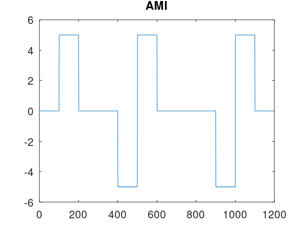

## График сигнала и результат расчёта

- График используется для сравнения формы и частотных свойств сигнала.

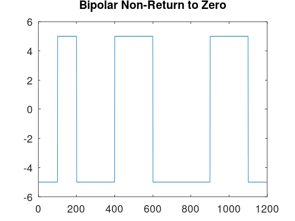

## График сигнала и результат расчёта

- График используется для сравнения формы и частотных свойств сигнала.

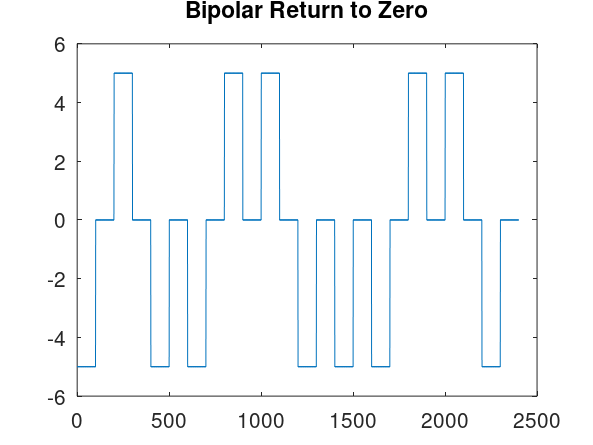

## График сигнала и результат расчёта

- В Differential Manchester информация задаётся расположением переходов.

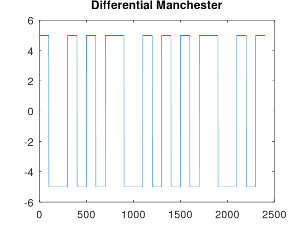

## График сигнала и результат расчёта

- График используется для сравнения формы и частотных свойств сигнала.

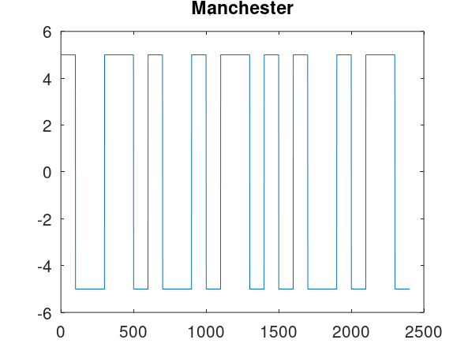

## Спектральное представление линейного кода

- График используется для сравнения формы и частотных свойств сигнала.

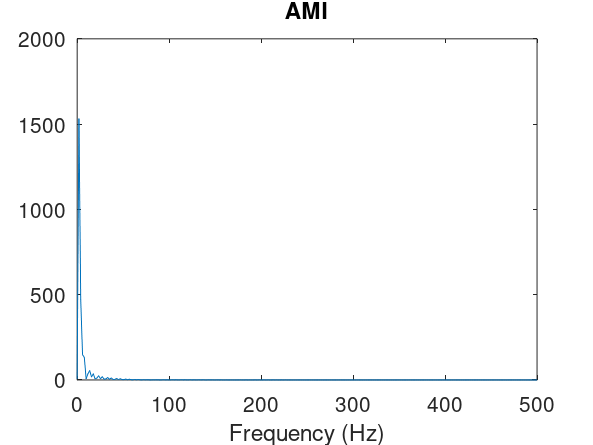

## Спектральное представление линейного кода

- Спектр bipolar NRZ сосредоточен преимущественно у низких частот.

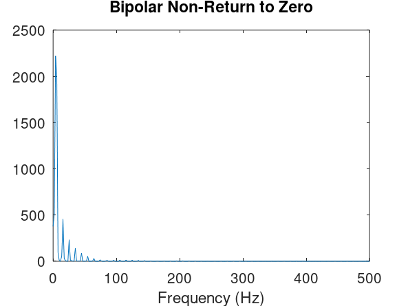

## Спектральное представление линейного кода

- График используется для сравнения формы и частотных свойств сигнала.

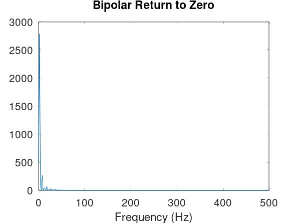

## Спектральное представление линейного кода

- График используется для сравнения формы и частотных свойств сигнала.

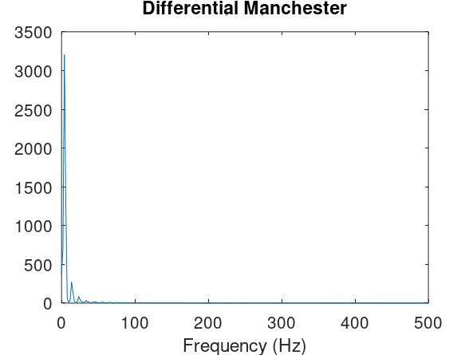

## Спектральное представление линейного кода

- Спектр Manchester отражает частые переходы сигнала.

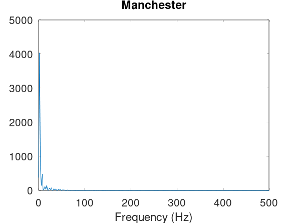

## Спектральное представление линейного кода

- График используется для сравнения формы и частотных свойств сигнала.

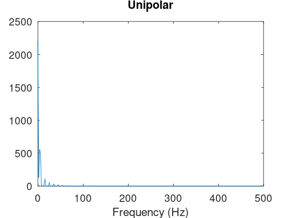

## Проверка самосинхронизации

- График используется для сравнения формы и частотных свойств сигнала.

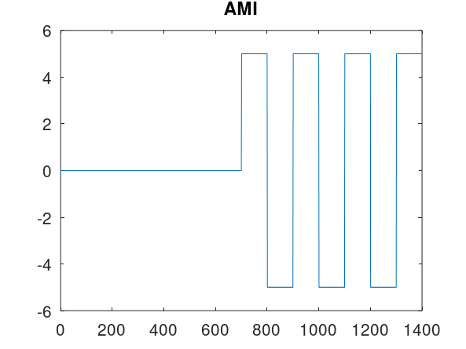

## Проверка самосинхронизации

- В bipolar NRZ длинные серии уменьшают число тактовых переходов.

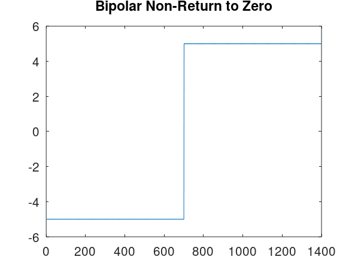

## Проверка самосинхронизации

- График используется для сравнения формы и частотных свойств сигнала.

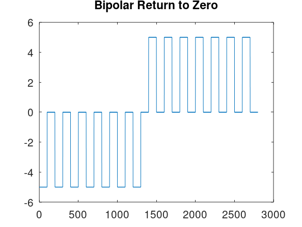

## Проверка самосинхронизации

- График используется для сравнения формы и частотных свойств сигнала.

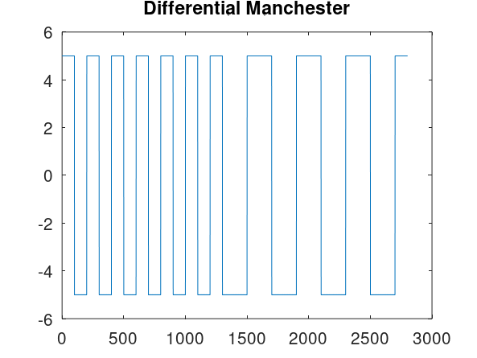

## Проверка самосинхронизации

- Manchester гарантирует переход внутри каждого бита.

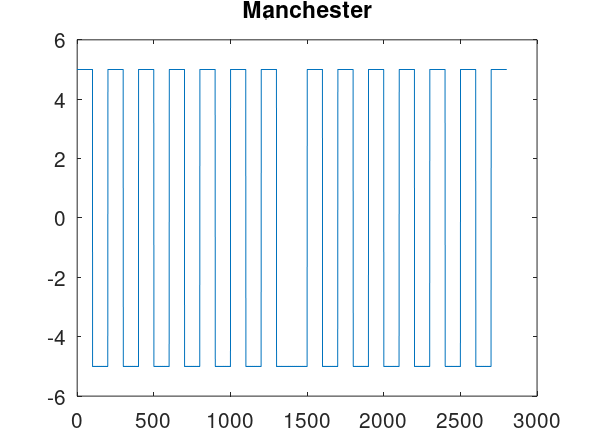

## Проверка самосинхронизации

- График используется для сравнения формы и частотных свойств сигнала.

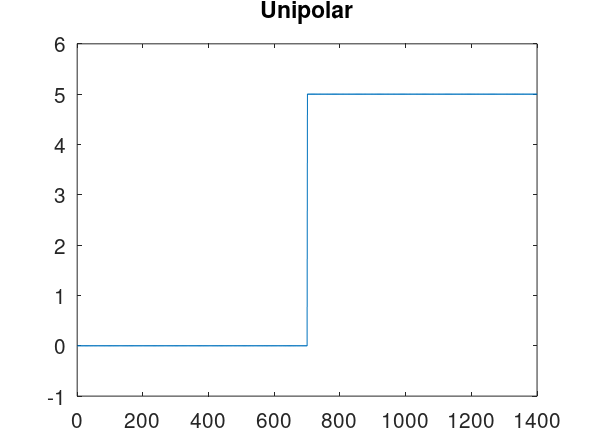

## График сигнала и результат расчёта

- График используется для сравнения формы и частотных свойств сигнала.

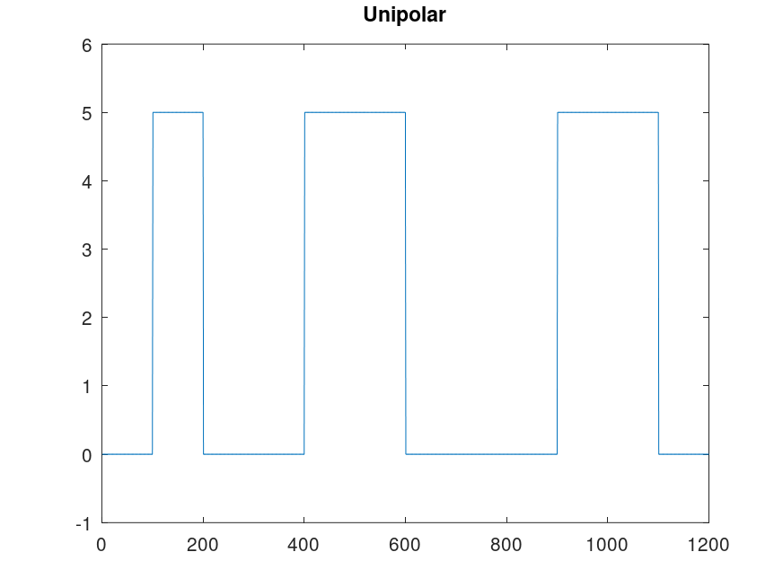

## График сигнала и результат расчёта

- На исходном графике отмечены дискретные отсчёты y1.

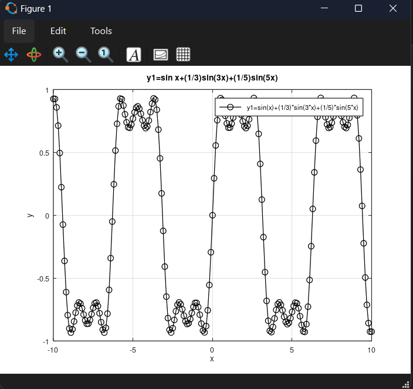

## График сигнала и результат расчёта

- График используется для сравнения формы и частотных свойств сигнала.

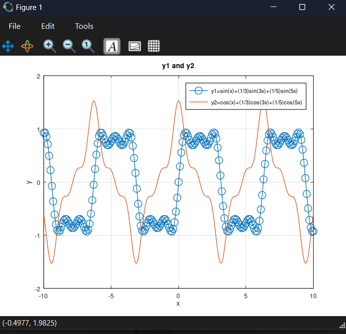

## График сигнала и результат расчёта

- График используется для сравнения формы и частотных свойств сигнала.

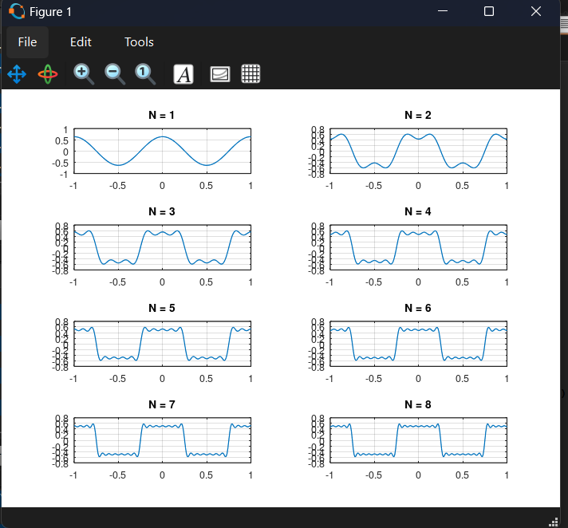

## График сигнала и результат расчёта

- Второй набор N=1…8 уточняет приближение рядом Фурье.

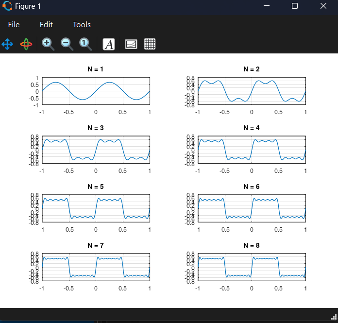

## График сигнала и результат расчёта

- График используется для сравнения формы и частотных свойств сигнала.

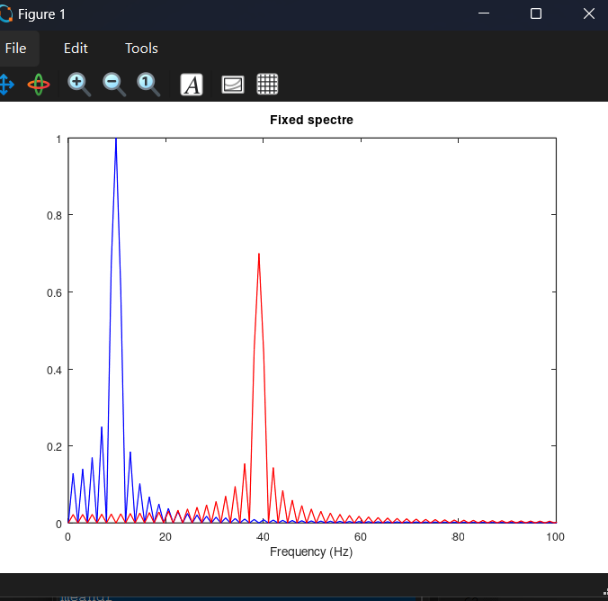

## График сигнала и результат расчёта

- График используется для сравнения формы и частотных свойств сигнала.

[figure not shown]

## График сигнала и результат расчёта

- Два главных спектральных пика соответствуют компонентам 10 и 40 Гц.

[figure not shown]

## График сигнала и результат расчёта

- График используется для сравнения формы и частотных свойств сигнала.

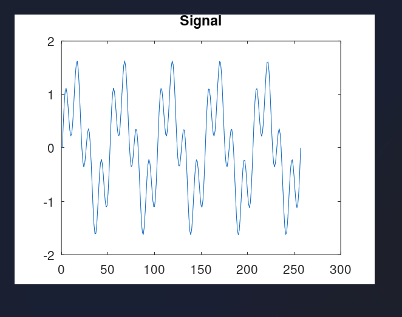

## График сигнала и результат расчёта

- График используется для сравнения формы и частотных свойств сигнала.

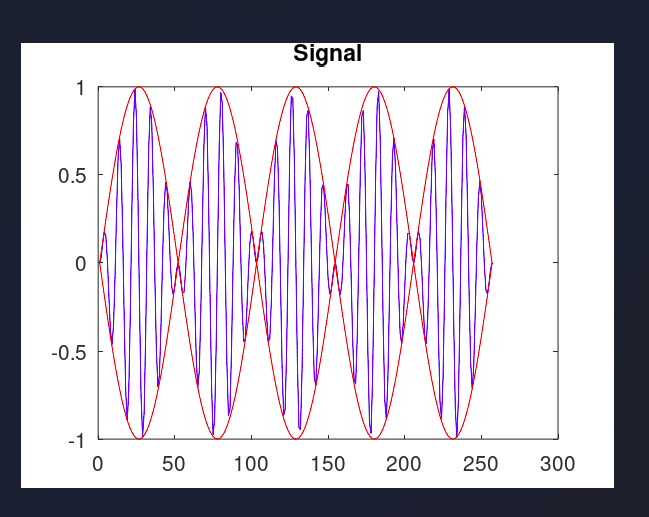

## График сигнала и результат расчёта

- AM-спектр содержит симметричные боковые полосы.

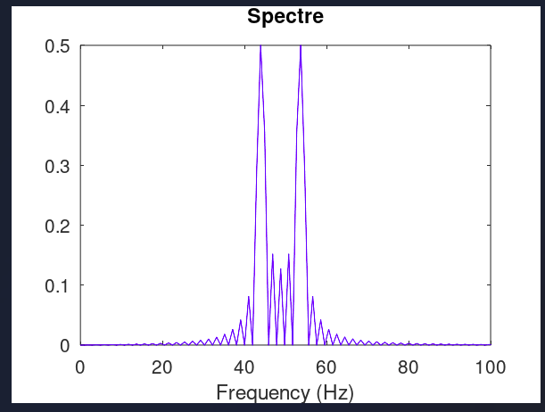

# Результаты

## Итоги работы

- Цель работы достигнута. Исследовать спектр, линейное кодирование, амплитудную модуляцию и самосинхронизацию в Octave Полученные результаты подтверждают работоспособность собранной схемы и корректность выполненной настройки.

## Спасибо за внимание